# PrMachLearning - Course Project

Giovanni Valentini

Tuesday, November 17, 2015

### Practical Machine Learning Class - November 2015

### Prediction Assignment Writeup

### Introduction

This project shows the analysis I performed in order to build a predictive model. The data come from a research about “Qualitative Activity Recognition” of weight lifting exercises. The goal of the model is to predict the quality of executing the exercise, as assessed by a factor variable called **“classe”** in the training dataset. The predictors are derived from features recorded by on-body sensors (accelerometers). In the analysis I used the `caret` R package.

### Selection of the predictors

The following code reads the data and stores them in 2 datasets:  
1. **training** which will be split in 2 sets in order to train and test the model  
2. **testing** which contains the 20 test cases to predict

```r
library(caret)
training <- read.csv("./pml-training.csv")
testing <- read.csv("./pml-testing.csv")
```

The number of variables is very large (there are 160 columns in the **training** dataset):

```r
dim(training)
```

```
## [1] 19622   160
```

In order to select the features for my model I followed 2 steps:  
1. I removed the variables with **near zero variance**

```r
nz <- nearZeroVar(training)
training <- training[, -nz]
testing <- testing[, -nz]
dim(training)
```

```
## [1] 19622   100
```

2. I removed the variables with a large number of **NA values**.  
   The number of NAs for each column is stored in the variable `a`.

```r
a <- rep(0, dim(training)[2])
for (j in 1:dim(training)[2]) {
  a[j] <- sum(is.na(training[, j]))
}
```

The following plot shows that 41 columns have more than 19000 NA values, and I decided to remove the corresponding variables:

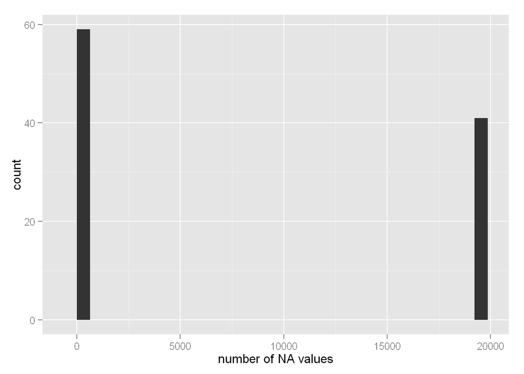

```r
qplot(a, xlab = "number of NA values")
```

```r
table(a < dim(training)[1] - 500)
```

```
##
## FALSE  TRUE
##    41    59
```

```r
training <- training[, a < dim(training)[1] - 500]
testing <- testing[, a < dim(training)[1] - 500]
dim(training)
```

```
## [1] 19622    59
```

I point out that the first 6 among the remaining 59 columns are not relevant as predictors, and I excluded them:

```r
str(training[,1:6])
```

```
## 'data.frame':    19622 obs. of  6 variables:
##  $ X                   : int  1 2 3 4 5 6 7 8 9 10 ...
##  $ user_name           : Factor w/ 6 levels "adelmo","carlitos",..: 2 2 2 2 2 2 2 2 2 2 ...
##  $ raw_timestamp_part_1: int  1323084231 1323084231 1323084231 1323084232 1323084232 1323084232 1323084232 1323084232 1323084232 1323084232 ...
##  $ raw_timestamp_part_2: int  788290 808298 820366 120339 196328 304277 368296 440390 484323 484434 ...
##  $ cvtd_timestamp      : Factor w/ 20 levels "02/12/2011 13:32",..: 9 9 9 9 9 9 9 9 9 9 ...
##  $ num_window          : int  11 11 11 12 12 12 12 12 12 12 ...
```

### Building the model and preprocessing with PCA

In order to use a **Cross-Validation** approach I split the training dataset into 2 sets:  
1. **trainSet** used to train the model  
2. **testSet** used to test the model

```r
set.seed(125)
inTrain <- createDataPartition(y = training$classe,
                               p = 0.75, list = FALSE)
trainSet <- training[inTrain, 7:59]
testSet <- training[-inTrain, 7:59]
which(names(trainSet) == "classe")
```

```
## [1] 53
```

The following matrix `V` shows that there is a high correlation between some of the selected variables.

```r
V <- abs(cor(trainSet[,-53]))
table(V > 0.7 & V < 1.0)
```

```
##
## FALSE  TRUE
##  2626    78
```

This led me to use **Principal Components Analysis (PCA)** as a pre-processing method, in order to find a new set of **uncorrelated predictors** which explain about 95% of the original variance (argument thresh = 0.95 in the preProcess function).

```r
xpca <- preProcess(trainSet[,-53], method = "pca",
                   thresh = 0.95)
trainPCA <- predict(xpca, trainSet[,-53])
xpca
```

```
## Created from 14718 samples and 52 variables
##
## Pre-processing:
##   - centered (52)
##   - principal component signal extraction (52)
##   - scaled (52)
##
## PCA needed 25 components to capture 95 percent of the variance
```

### Training the model - method “rpart”

In my first attempt I use method **rpart** to train the model. I use method “cv” (cross-validation) and number = 3 (k parameter) in **trainControl** function, in order to control the computational aspects of the train function.

```r
modFit <- train(trainSet$classe ~ ., data = trainPCA,
                method = "rpart",
                trControl = trainControl(method = "cv", number = 3))
testPCA <- predict(xpca, testSet[,-53])
confusionMatrix(testSet$classe, predict(modFit,testPCA))
```

```
## Confusion Matrix and Statistics
##
##           Reference
## Prediction    A    B    C    D    E
##          A 1275    0    0  114    6
##          B  636    0    0  187  126
##          C  787    0    0   55   13
##          D  425    0    0  316   63
##          E  497    0    0  155  249
##
## Overall Statistics
##
##                Accuracy : 0.3752
##                  95% CI : (0.3616, 0.3889)
##     No Information Rate : 0.7382
##     P-Value [Acc > NIR] : 1
##
##                   Kappa : 0.1616
##  Mcnemar's Test P-Value : NA
##
## Statistics by Class:
##
##                      Class: A Class: B Class: C Class: D Class: E
## Sensitivity            0.3522       NA       NA  0.38210  0.54486
## Specificity            0.9065   0.8065   0.8257  0.88030  0.85338
## Pos Pred Value         0.9140       NA       NA  0.39303  0.27636
## Neg Pred Value         0.3317       NA       NA  0.87537  0.94804
## Prevalence             0.7382   0.0000   0.0000  0.16864  0.09319
## Detection Rate         0.2600   0.0000   0.0000  0.06444  0.05077
## Detection Prevalence   0.2845   0.1935   0.1743  0.16395  0.18373
## Balanced Accuracy      0.6294       NA       NA  0.63120  0.69912
```

The accuracy of the model is quite low: **0.3752**, and the estimate of the **out of sample error** is obtained as `1 - accuracy` and then is:

```
## [1] 0.6248
```

The accuracy is too low to correctly predict, and I decide to use a new model.

### Training the model - method Random Forest

In my second attempt I use the method **Random Forest** to train the model.  
I use method “cv” (cross-validation) and number = 3 (k parameter) in **trainControl** function, in order to control the computational aspects of the train function.

```r
modFitRF <- train(trainSet$classe ~ ., data = trainPCA,
                  method = "rf",
                  trControl = trainControl(method = "cv", number = 3))
pred <- predict(modFitRF, testPCA)
confusionMatrix(testSet$classe, pred)
```

```
## Confusion Matrix and Statistics
##
##           Reference
## Prediction    A    B    C    D    E
##          A 1388    0    4    3    0
##          B   16  916   16    0    1
##          C    1    8  833   13    0
##          D    0    3   37  763    1
##          E    0    0    8    9  884
##
## Overall Statistics
##
##                Accuracy : 0.9755
##                  95% CI : (0.9708, 0.9797)
##     No Information Rate : 0.2865
##     P-Value [Acc > NIR] : < 2.2e-16
##
##                   Kappa : 0.969
##  Mcnemar's Test P-Value : NA
##
## Statistics by Class:
##
##                      Class: A Class: B Class: C Class: D Class: E
## Sensitivity            0.9879   0.9881   0.9276   0.9683   0.9977
## Specificity            0.9980   0.9917   0.9945   0.9900   0.9958
## Pos Pred Value         0.9950   0.9652   0.9743   0.9490   0.9811
## Neg Pred Value         0.9952   0.9972   0.9839   0.9939   0.9995
## Prevalence             0.2865   0.1890   0.1831   0.1607   0.1807
## Detection Rate         0.2830   0.1868   0.1699   0.1556   0.1803
## Detection Prevalence   0.2845   0.1935   0.1743   0.1639   0.1837
## Balanced Accuracy      0.9929   0.9899   0.9611   0.9792   0.9968
```

The accuracy of the model is very high, over **0.97** and consequently the estimate of the *out of sample error* is under **0.03**.  
The following plot shows the **right predictions** of testSet outcomes (green colour):

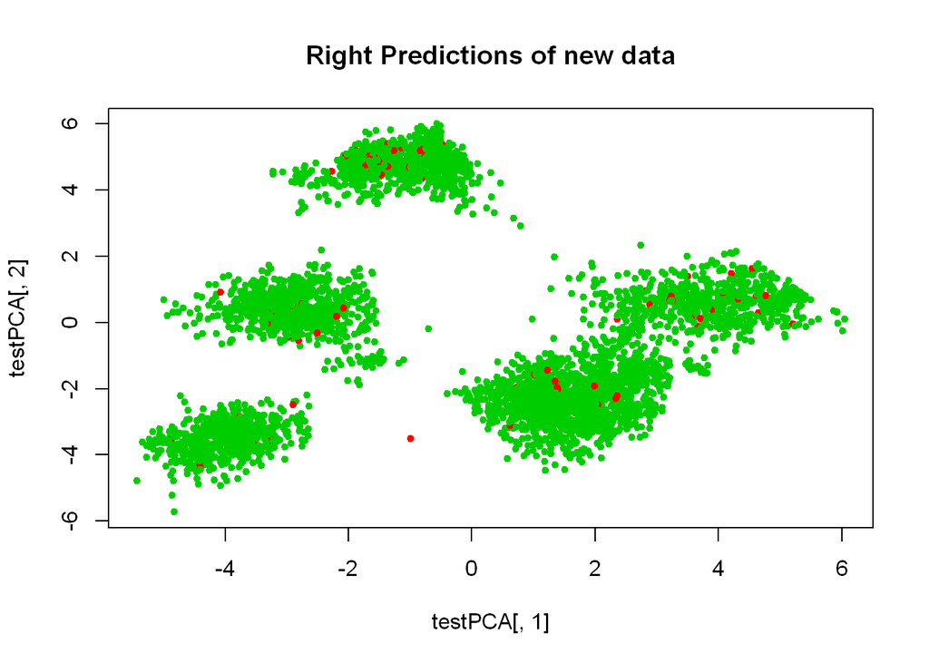

```r
predRight <- (pred == testSet$classe)*1 + 2
plot(testPCA[,1], testPCA[,2], col=predRight, pch=20,
     main = "Right Predictions of new data")
```

This approach seems to be very effective and I use the model based on **Random Forest** to predict the 20 test cases to submit:

```r
testingPCA <- predict(xpca, testing[,7:58])
myAnswers <- predict(modFitRF, newdata = testingPCA)
myAnswers
```

```
##  [1] B A C A A E D B A A B C B A E E A B B B
## Levels: A B C D E
```